# Homework 10

Brandon Simelgor

2023-04-20

Brandon Simelgor https://github.com/Simelgor05/Homework-10.git

```r
vehicle <- read.csv("https://raw.githubusercontent.com/yumouqiu/DS202-Spring2023/main/Practice/data/fars2016/vehicle.csv")
accident <- read.csv("https://raw.githubusercontent.com/yumouqiu/DS202-Spring2023/main/Practice/data/fars2016/accident.csv")
person <- read.csv("https://raw.githubusercontent.com/yumouqiu/DS202-Spring2023/main/Practice/data/fars2016/person.csv")
```

Part one: Accident data are there some days of the week where more accidents happen than on others (use variable DAY_WEEK)?

```r
library(tidyverse)
head(accident)
```

```
##   STATE ST_CASE VE_TOTAL VE_FORMS PVH_INVL PEDS PERNOTMVIT PERMVIT PERSONS
## 1     1   10001        1        1        0    0          0       1       1
## 2     1   10002        1        1        0    0          0       2       2
## 3     1   10003        2        1        1    0          1       1       2
## 4     1   10004        1        1        0    0          0       1       1
## 5     1   10005        1        1        0    0          0       1       1
## 6     1   10006        1        1        0    0          0       1       1
##   COUNTY CITY DAY MONTH YEAR DAY_WEEK HOUR MINUTE NHS RUR_URB FUNC_SYS RD_OWNER
## 1     73 1716   1     1 2016        6    9     25   1       2        1        1
## 2     73 1716  10     1 2016        1   19     59   1       2        1        1
## 3     73    0   1     1 2016        6    2     20   1       1        1        1
## 4     73    0  17     1 2016        1   21     45   1       1        1        1
## 5     73 3125  26     1 2016        3   20      7   1       2        1        1
## 6    109    0   1     1 2016        6    1     10   0       1        4        1
##   ROUTE TWAY_ID   TWAY_ID2 MILEPT LATITUDE  LONGITUD SP_JUR HARM_EV MAN_COLL
```

[output cut: 27 more lines]

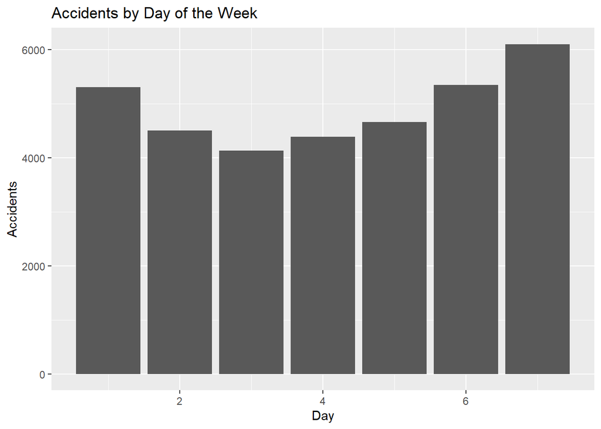

```r
accidentday <- accident %>%
  group_by(DAY_WEEK) %>%
  summarize(total_accidents = n())

ggplot(accidentday, aes(x = DAY_WEEK, y = total_accidents)) +
  geom_bar(stat = "identity") +
  xlab("Day") +
  ylab("Accidents") +
  ggtitle("Accidents by Day of the Week")
```

The days of the week where accidents happened more often were days 1, 6, and 7.

what time of the day do accidents happen (use variable HOUR)?

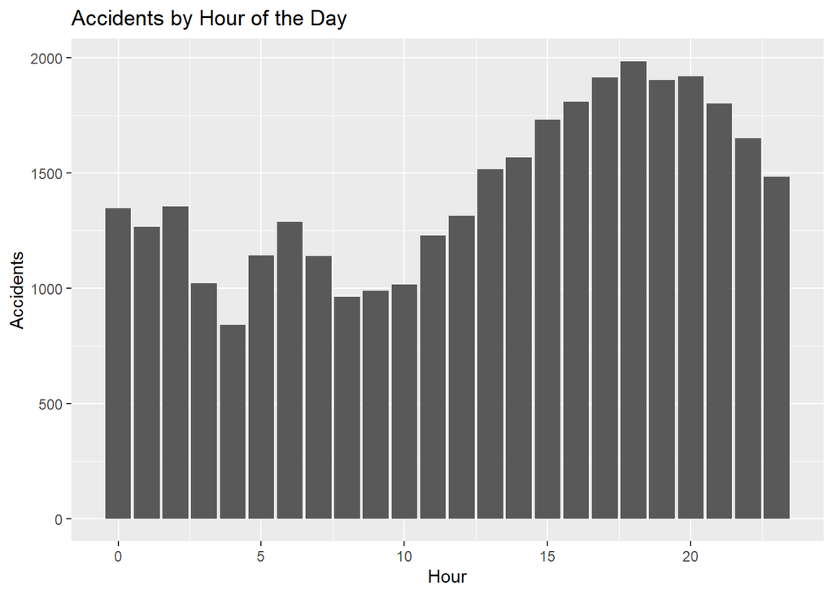

```r
accidentshour <- accident %>%
  filter(HOUR != 99) %>%
  group_by(HOUR) %>%
  summarize(total_accidents = n())

ggplot(accidentshour, aes(x = HOUR, y = total_accidents)) +
  geom_bar(stat = "identity") +
  xlab("Hour") +
  ylab("Accidents") +
  ggtitle("Accidents by Hour of the Day")
```

Accidents occured during every hour of the day but most frequently in th evening between the 15th and 24th hours of the day.

what is the number of accidents with at least one drunk driver (use variable DRUNK_DR)?

```r
accidentsdrunkdriver <- accident %>%
  filter(DRUNK_DR > 0) %>%
  nrow()

accidentsdrunkdriver
```

```
## [1] 8720
```

There are 8720 accidents with at least one drunk driver.

Part two: Connecting data Connect to the person table. Identify drivers (PER_TYP == 1, see fars manual ) and subset on them.

```r
head(person)
```

```
##   STATE ST_CASE VE_FORMS VEH_NO PER_NO STR_VEH COUNTY DAY MONTH HOUR MINUTE
## 1     1   10001        1      1      1       0     73   1     1    9     25
## 2     1   10002        1      1      1       0     73  10     1   19     59
## 3     1   10002        1      1      2       0     73  10     1   19     59
## 4     1   10003        1      1      1       0     73   1     1    2     20
## 5     1   10003        1      2      1       0     73   1     1    2     20
## 6     1   10004        1      1      1       0     73  17     1   21     45
##   RUR_URB FUNC_SYS HARM_EV MAN_COLL SCH_BUS MAKE MAK_MOD BODY_TYP MOD_YEAR
## 1       2        1      42        0       0   20   20401       14     2002
## 2       2        1       1        0       0   37   37031        4     2008
## 3       2        1       1        0       0   37   37031        4     2008
## 4       1        1      14        0       0   20   20481       31     2008
## 5       1        1      14        0       0   82   82881       66     2016
## 6       1        1      25        0       0   20   20481       31     2000
##   TOW_VEH SPEC_USE EMER_USE ROLLOVER IMPACT1 FIRE_EXP AGE SEX PER_TYP INJ_SEV
```

[output cut: 41 more lines]

```r
head(person) %>% filter(PER_TYP ==1)
```

```
##   STATE ST_CASE VE_FORMS VEH_NO PER_NO STR_VEH COUNTY DAY MONTH HOUR MINUTE
## 1     1   10001        1      1      1       0     73   1     1    9     25
## 2     1   10002        1      1      1       0     73  10     1   19     59
## 3     1   10003        1      1      1       0     73   1     1    2     20
## 4     1   10004        1      1      1       0     73  17     1   21     45
##   RUR_URB FUNC_SYS HARM_EV MAN_COLL SCH_BUS MAKE MAK_MOD BODY_TYP MOD_YEAR
## 1       2        1      42        0       0   20   20401       14     2002
## 2       2        1       1        0       0   37   37031        4     2008
## 3       1        1      14        0       0   20   20481       31     2008
## 4       1        1      25        0       0   20   20481       31     2000
##   TOW_VEH SPEC_USE EMER_USE ROLLOVER IMPACT1 FIRE_EXP AGE SEX PER_TYP INJ_SEV
## 1       0        0        0        1       8        0  37   2       1       4
## 2       0        0        0        1       0        0  24   1       1       3
## 3       0        0        0        0      12        0  22   1       1       4
## 4       0        0        0        0      12        0  36   1       1       4
```

[output cut: 25 more lines]

Join accident and driver table (work out which variable(s) to use)

```r
head(vehicle)
```

```
##   STATE ST_CASE VEH_NO VE_FORMS NUMOCCS DAY MONTH HOUR MINUTE HARM_EV MAN_COLL
## 1     1   10001      1        1       1   1     1    9     25      42        0
## 2     1   10002      1        1       2  10     1   19     59       1        0
## 3     1   10003      1        1       1   1     1    2     20      14        0
## 4     1   10004      1        1       1  17     1   21     45      25        0
## 5     1   10005      1        1       1  26     1   20      7      42        0
## 6     1   10006      1        1       1   1     1    1     10      42        0
##   UNITTYPE HIT_RUN REG_STAT OWNER MAKE MODEL MAK_MOD BODY_TYP MOD_YEAR
## 1        1       0        1     2   20   401   20401       14     2002
## 2        1       0        1     1   37    31   37031        4     2008
## 3        1       0        1     1   20   481   20481       31     2008
## 4        1       0        1     1   20   481   20481       31     2000
## 5        1       0        1     3   20   481   20481       31     1995
## 6        1       0        1     1   49   472   49472       30     2009
##            VIN VIN_1 VIN_2 VIN_3 VIN_4 VIN_5 VIN_6 VIN_7 VIN_8 VIN_9 VIN_10
```

[output cut: 69 more lines]

```r
accidentvehicle <- left_join(accident, vehicle, by = "ST_CASE")
```

Tally the number of accidents by day of the week (DAY_WEEK), hour of the day (HOUR) and gender (SEX). Visualize the results!

```r
accidentsdayhourgender <- person %>%
  filter(HOUR != 99) %>%
  filter(SEX != 8) %>%
  filter(SEX != 9) %>%
  left_join(accidentvehicle, by = "ST_CASE") %>%
  group_by(DAY_WEEK, HOUR, SEX) %>%
  summarize(num_accidents = n())
accidentsdayhourgender
```

```
## # A tibble: 336 × 4
## # Groups:   DAY_WEEK, HOUR [168]
##    DAY_WEEK  HOUR   SEX num_accidents
##       <int> <int> <int>         <int>
##  1        1     0     1           690
##  2        1     0     2           316
##  3        1     1     1           698
##  4        1     1     2           324
##  5        1     2     1           926
##  6        1     2     2           382
##  7        1     3     1           616
##  8        1     3     2           243
##  9        1     4     1           413
## 10        1     4     2           169
## # … with 326 more rows
```

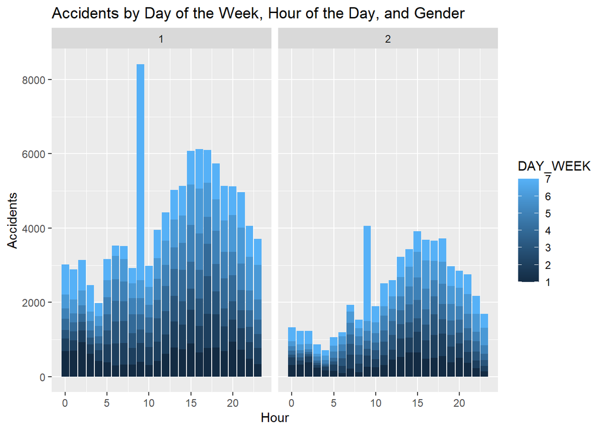

```r
ggplot(accidentsdayhourgender, aes(x = HOUR, y = num_accidents, fill = DAY_WEEK)) +
  facet_wrap(~SEX)+
  geom_bar(stat = "identity", position = "stack") +
  xlab("Hour") +
  ylab("Accidents") +
  ggtitle("Accidents by Day of the Week, Hour of the Day, and Gender")
```